# 1_Scatterplots_Hisograms_Barplots

#### Facetting by more than one variable:

If you need to, you may split your data by more than one categorical variables. In this case you need to specify a **vector of characters (strings)** containing the names of the variables used for sub-setting. You can attain this in R using the function `c()` (*combine*).

The problem with this is two-fold:

1. Your sub-sets of data might get too small if you specify many categorical variables for sub-setting. You need to ponder if that level of sub-setting is appropriate for your dataset.
2. The combination of unique values for both categorical variables may result in a lot of sub-graphs. You may need to re-scale the output.

Let us for example create the same scatterplot with the `mpg` dataset, but this time let us `facet_wrap` by both engine drive (`drv`) and number of cylinders (`cyl`):

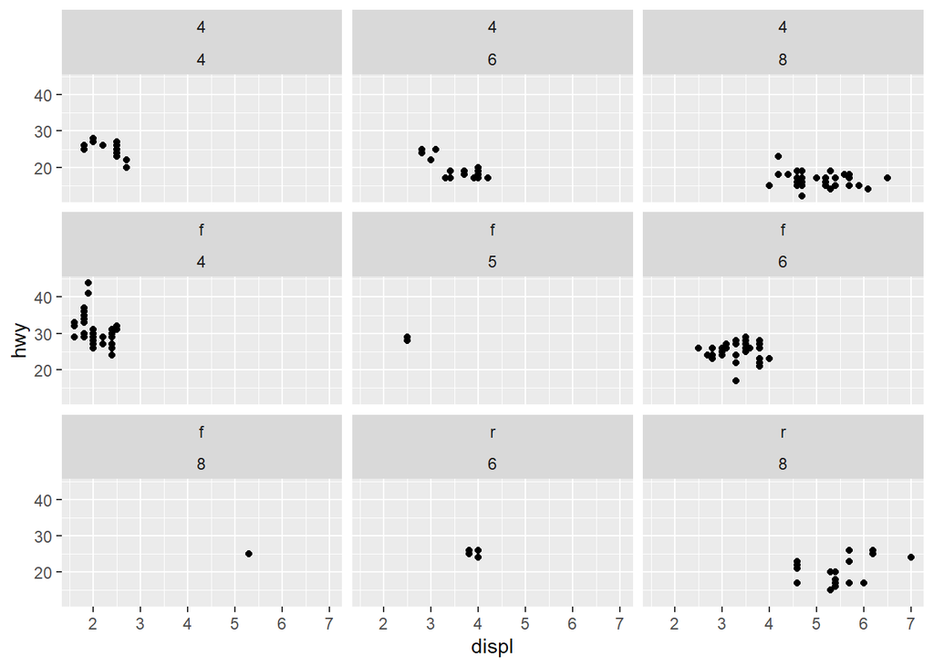

```r
ggplot(mpg, aes(displ, hwy)) +
  geom_point() +
  facet_wrap(c("drv", "cyl"))
```

The title of each scatterplot gives us the specific combination of the variables `drv` and `cyl` to which the scatterlpot corresponds. See for example how there are very few cars with front wheel drive and 5 cylinders (`f` `5`), resulting in a scatterplot that is barely populated. The same occurs for cars with front-wheel drive and 8 cylinders (`f` `8`). This is one of the risks of faceting by too many variables, some of your subsets of data may become too small.